# Introduction to DirichletProcess package in R

This tutorial will cover the theoretical background of Dirichlet Processes (DPs), the installation and basic usage of the `dirichletprocess` package, and delve into examples of density estimation and clustering with Bayesian non-parametrics.

Dirichlet processes stand as a fundamental concept in Bayesian non-parametric statistics, offering a flexible approach to modeling data distributions without predefining the number of parameters. The `dirichletprocess` package in R facilitates the fitting of complex Bayesian non-parametric models, streamlining the process for users by eliminating the need for custom inference algorithm programming.

### Purpose and Features of `dirichletprocess` Package

A variety of simulation algorithms based around Gibbs sampling and Metropolis-Hastings have been developed to draw samples from DPMM posterior distributions, which can then be used for inference. The purpose of the `dirichletprocess` package is to provide a unified implementation of these simulation algorithms for a very wide class of DP mixture models which makes it easy to incorporate DPMMs into hierarchical models.

Key features of the `dirichletprocess` package include:

- An implementation of DP mixture models for various types of mixture kernel including the Gaussian, Beta, Multivariate Normal and Weibull.
- Implementation of DP posterior sampling algorithms in both the conjugate and non-conjugate cases.
- A object-based interface which allows the user to work directly with DP objects in R so that they can be incorporated into hierarchical models.

## Theoretical Background

### Dirichlet Process

A Dirichlet Process (DP) is essentially a distribution over distributions. Each sample from a DP is a distribution itself, making DPs particularly suitable for non-parametrically modeling unknown probability distributions.

The basic DP model has the form:
$$y_i
\sim F , \ \ F \sim DP(\alpha, G_0)$$

where $G_0$ is known as the base measure and encapsulates any prior knowledge that might be known about F. Specifically, it can be shown that $\mathbb{E}[F | G_0,\alpha] = G_0$. The concentration parameter $\alpha$ specifies the prior variance and controls the relative contribution that the prior and data make to the posterior, as the following result shows:

- **Key Property 1** : The DP is a conjugate prior in the following sense: if $y_1, . . . , y_n \sim F$ and $F \sim DP(\alpha, G_0)$, then:
  $$F | y_1, . . . , y_n
  \sim DP \Big( \alpha + n, \frac{\alpha G_0 + \sum_{i=1}^{n}
  \delta_{y_i}}{ \alpha + n} \Big)$$
  where $\delta_{y_i}$ denotes a point-mass at $y_i$. In other words, the posterior distribution of F is a weighted sum of the base measure $G_0$ and the empirical distribution of the data, with the weighting controlled by $\alpha$.

The DP is a prior distribution over the space of probability distributions. As such, samples from a DP are probability distributions. The stick-breaking representation first introduced by Sethuraman (1994) shows what such samples look like:

- **Key Property 2** : Suppose that $F \sim DP(\alpha, G)$ is a random probability distribution sampled from a DP prior. Then with probability 1, $F$ can be written as:
  $$F = \sum_{k=1}^{\infty} w_k \delta_{\phi_k}, \ \
  \ \phi_k \sim G_0$$
  where
  $$w_k = z_k
  \prod_{i=1}^{k-1} (1 - z_i), \ \ \ z_i \sim Beta(1,
  \alpha)$$

The stick-breaking representation shows that a sample from a DP is a weighted sum of point masses, where the weights are given by a sequence of beta-distributed random variables and the locations of the point masses are drawn from the base measure $G_0$. The weights are such that the sum of the weights is 1, so that the sample is a probability distribution.

By combining Key Properties 1 and 2, we can sample a DP from its posterior distribution $F | y_1, . . . , y_n$ as follows:

- **Key Property 3** : If $y_1, . . . , y_n \sim F$ and $F \sim DP(\alpha, G_0)$ then we can draw a (truncated) sample probability distribution from the posterior $F | y_1, . . . , y_n$ as follows:
  $$F = \sum_{k=1}^{N} w_k \delta_{\phi_k}, \ \ \
  \phi_k \sim \alpha G_0 + \sum_{i=1}^{n} \delta_{y_i}$$
  where
  $$w_k = z_k \prod_{i=1}^{k-1} (1 - z_i), \ \
  \ z_i \sim Beta(1, \alpha + n)$$
  and $N$ is a truncation parameter.

### Dirichlet Process Mixtures

The stick breaking representation in Key Property 2 above shows that probability distributions sampled from a DP are discrete with probability 1. As such, the DP is not an appropriate prior for $F$ when $F$ is continuous. Therefore, it is usual to adopt the following mixture specification instead, which is known as the Dirichlet process mixture model (DPMM):
$$y_i \sim k(y_i | \theta _i ) , \ \ \theta_i
\sim F , \ \ F \sim DP ( \alpha , G_0)$$

where $k(· | \theta)$ denotes the mixture kernel, and the mixing distribution $G$ is assigned a non-parametric Dirichlet process prior with a base measure $G_0$ and concentration parameter $\alpha$.The most commonly used example is the Gaussian mixture model where $\theta_i = (\mu_i, \sigma^2_i)$ so that $k(y_i | \theta_i) = N(y_i | \mu_i, \sigma^2_i)$.

The key point here is that since $F$ is discrete, two independent draws $\theta_i$ and $\theta_j$ from F can have identical values with a non-zero probability. As such, the DPMM can be seen as sorting the data into clusters, corresponding to the mixture components. The above model can hence be written equivalently as the following mixture model, which is infinite dimensional can hence be viewed as a generalization of the finite mixture models commonly used in nonparametric statistics:
$$y_i \sim G , \ \
G = \int k(y_i | \theta)F(d\theta), \ \ F \sim DP(\alpha,
G_0)$$

When the DPMM is used in practice, interest may focus on several different parameters of the posterior distribution. In some cases, the primary object of interest will be all n of the $\theta_i$ parameters which are associated with the n observations. However in other situations it will be the distribution F which is of primary interest. The `dirichletprocess` package returns posterior samples of all these quantities, so that the user can decide which are most relevant.

Posterior inference in the `dirichletprocess` package is based around the Chinese Restaurant Process sampler (Neal 2000). This is a Gibbs-style algorithm based on the DPMM representation above, and draws samples of $\theta_1, . . . , \theta_n$ from their posterior with the distribution $F$ integrated out.

- **Key Property 4** :Let $\theta_{-i}$ denote the set of $\theta$ values with $\theta_i$ excluded, i.e. $\theta_{-i} = (\theta_1, . . . , \theta_{i-1}, \theta_{i+1}, . . . , \theta_n)$. Then the posterior distribution for $\theta_i$ conditional on the other model parameters is:
  $$p(\theta_i | \theta_{-i}, y_{1:n}, \alpha, G_0)
  = \sum_{j \neq i} q_{i,j} \delta(\theta_j) + r_i H_i$$
  $$q_{i,j} = bk(y_i , \theta_j ) , \ \ r_i = b
  \alpha \int k(y_i , \theta)dG_0(\theta)$$
  where $b$ is set such that $\sum_{j \neq i} q_{i,j} + r_i =1$ and $H_i$ is the posterior distribution of $\theta_i$ based off of the prior base measure $G_0$

Based on this result, Gibbs sampling is used to repeatedly draw each value of $\theta_i$ in turn from its posterior distribution, with all other variables held constant. An important distinction needs to be made between the **conjugate** case where the $G_0$ base measure is the conjugate prior for $\theta$ with respect to the kernel $k(·)$, and the **non-conjugate** case there is not a closed form for the posterior distribution. The `dirichletprocess` package handles the non-conjugate case by using “Algorithm 8” from (Neal 2000), which is one of the most widely used techniques for performing this sampling.

In both the conjugate and non-conjugate cases, the Gibbs sampling is conceptually similar, with the new values of $\theta_i$ being proposed sequentially from their respective posterior distributions. However in practice, this can result in poor mixing of the Gibbs sampler. So we can’t directly use JAGS or rStan to sample from the posterior distribution of the DPMM.

For simple density estimation and non-hierarchical predictive tasks, having a posterior sample of $\theta_{1:n}$ will be sufficient for inference, and the distribution $F$ is not of any intrinsic interest. However when the DP is used as part of a hierarchical model such as in the regression and point process examples we discuss later, it is also necessary to have samples from the posterior distribution of F. These can be obtained using the following property:

- **Key Property 5** : Given the model, let $\theta_1, . . . , \theta_n$ be a sample from the posterior $p(\theta_1:n | y_1:n, \alpha, G_0)$ drawn using the CRP sampler. Then, $p(F | \theta_{1:n}, y_{1:n}, \alpha, G_0) = p(F | \theta_{1:n}, \alpha, G_0)$ is conditionally independent of $y_{1:n}$. As such, $\theta_{1:n}$ can be considered as an i.i.d sample from $F$, and so $F$ can be sampled from its posterior distribution using Key Property 3 above:
  $$F
  = \sum_{i=1}^{N} w_i \delta_{\theta_i}, \ \ w_i \sim Beta(\alpha + n,
  1), \ \ \theta_i \sim \alpha G_0 + \sum_{i=1}^{n}
  \delta_{\theta_i}$$
  where $N$ is again a truncation parameter.

## Package Overview

The `dirichletprocess` package contains implementations of a variety of Dirichlet process mixture models for nonparametric Bayesian analysis. Unlike several other R packages, the emphasis is less on providing a set of functions which completely automate routine tasks (e.g. density estimation or linear regression) and more on providing an abstract data type representation of Dirichlet process objects which allow them to be used as building blocks within hierarchical models.

### Getting Started

To begin using the `dirichletprocess` package, install it from CRAN and load it into your R session:

```r
#install.packages("dirichletprocess")
library(dirichletprocess)
library(MASS)
```

### *Example 1: Nonparametric Density Estimation*

we use the waiting times between eruptions of the Old Faithful volcano. This dataset is available within R and called **faithful**. We transform the waiting times to be be zero mean and and unit standard deviation and proceed to fit a DPMM with the default settings. We then model the waiting times as a mixture of Normal distributions

$$y_i \sim F , \\
F = \sum_{i=1}^{n} \pi_i k(y_i | \theta_i) , \ \ \theta_i = \{\mu_i ,
\sigma_i^2\}, \\
\theta_i \sim G, \\
G \sim DP(\alpha, G_0)$$

where $k(y_i | \theta)$ is the standard normal probability density and $G_0$ is the base measure.

```r
its <- 500
faithfulTransformed <- scale(faithful$waiting)
dp <- DirichletProcessGaussian(faithfulTransformed)
dp <- Fit(dp, its)
```

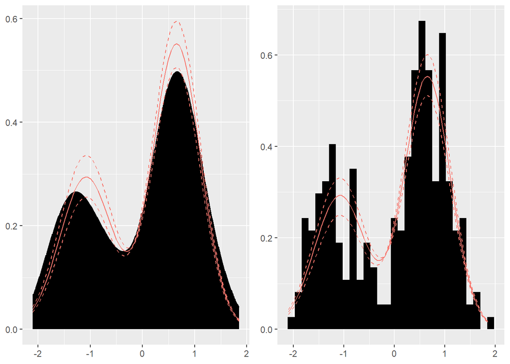

```r
library(gridExtra)
p1 <- plot(dp)
p2 <- plot(dp, data_method = "hist")
grid.arrange(p1, p2, ncol = 2)
```

After fitting, `dp` contains MCMC samples of cluster parameters, weights, and the concentration parameter $\alpha$. When plotting the resulting object, the plot function has the argument `data_method` which controls how the data is represented in the plot. In the default case it is a density estimation. For cases where the amount of data is limited, a density estimation may not be suitable, in which case, `data_method` should be set to `"hist"` for a histogram.

By default, the **Fit** function updates the cluster allocation, the cluster parameters and then the $\alpha$ parameter. In some rare cases, updating $\alpha$ every iteration can delay convergence. Instead, the user can instead choose to update $\alpha$ every 10 iterations.

```r
set.seed(123)
y <- rt(200, 3) + 2
dp <- DirichletProcessGaussian(y)
samples <- list()
for(s in seq_len(1000)){
  dp <- ClusterComponentUpdate(dp)
  dp <- ClusterParameterUpdate(dp)
  if(s %% 10 == 0) {
    dp <- UpdateAlpha(dp)
  }
  samples[[s]] <- list()
  samples[[s]]$phi <- dp$clusterParameters
  samples[[s]]$weights <- dp$weights
}
```

The function `ClusterComponentUpdate` iterates through all the data points,$y_i$ for $i = 1, . . . , n$, updating its cluster assignment sequentially via the Chinese Restaurant Process sampling algorithm, using Key Property 4.For each data point, it can either be assigned to an existing cluster, or form a new cluster. The function `ClusterParameterUpdate` updates the cluster parameters, and the function `UpdateAlpha` updates the concentration parameter $\alpha$.By manually calling these functions the user has control over the MCMC routine without having to have specific knowledge of the required algorithms.

The key point of the `dirichletprocess` package which the above code highlights is that a) the user controls when to re-sample the DP parameters, and b) the current sample is contained in the DP object and ready for inspection at any point in the code. This allows DP objects to be used as building blocks within hierarchical models.

In some situations it will be necessary to estimate densities on bounded intervals. For example, it might be known that the observations $y_i$ are restricted to lie within the interval $[0, 1]$. In this case, a mixture of Gaussian distributions is inappropriate, since this will assign positive probability to the whole real line. An alternative specification is a mixture of Beta distributions, since the Beta distribution only has positive mass in $[0, 1]$. The full model is the same as in the previous example but replacing $k$ with the Beta distribution.

### *Example 2: Cluster Analysis*

For any Dirichlet model, each data point $y_i$ is assigned a cluster parameter $\theta_i$ . The collection of unique values of cluster parameters $\theta_*$ allows for a natural way of grouping the data and hence the Dirichlet process is an effective way of performing cluster analysis. In the `dirichletprocess` package, the clustering labels is available at each fitting iteration and available to the user as `dp$clusterLabels`.

To demonstrate this we return to the faithful dataset which consists of two-dimensional data. In this example we also consider the length of the eruption as well as the amount of time between eruptions. The full model can be written as
$$y_i \sim N( y |
\theta_i) , \\
\theta_i = \{\mu_i , \Sigma_i\}, \\
\theta_i \sim G, \\
G \sim DP(\alpha, G_0)$$

where $G_0$ is the base measure and $\alpha$ is the concentration parameter.

We will be using the cluster labels to indicate which group each data point belongs to. We transform the data so that each variable is zero mean and unit standard deviation.

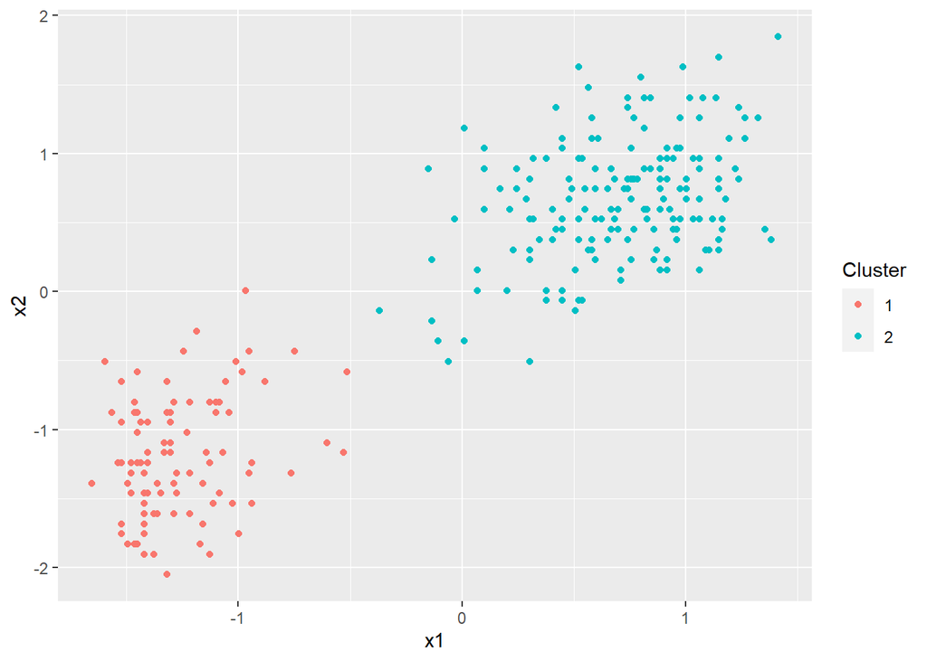

```r
faithfulTrans <- scale(faithful)
dp <- DirichletProcessMvnormal(faithfulTrans)
dp <- Fit(dp, 1000)
plot(dp)
```

### *Example 3: Hierarchical Dirichlet process*

A hierarchical Dirichlet process can be used for grouped data. Each individual dataset is modeled using a separate Dirichlet process but where the base measure itself is also a Dirichlet process. Mathematically this can be expressed as
$$y_{ij} ∼F(\theta_{ij} ), \\
\theta_{ij} ∼G_j , \\
G_j ∼DP(\alpha_j , G_0), \\
G_0 ∼DP(\gamma, H)$$

for each dataset $j = 1, . . . , n$ with data $y_{1_j} , \dots, y_{N_j}$ there is a separate Dirichlet process generating the required parameters $\theta_{ij}$.

In this example we create two synthetic data sets and fit a Hierarchical Dirichlet process to demonstrate the use of such a tool. In this case we are fitting a Beta Dirichlet mixture model and therefore simulate from two Beta distributions
$$y_1 ∼Beta(0.25, 5) + Beta(0.75, 6), \\
y_2 ∼Beta(0.25, 5) + Beta(0.4, 10)$$

where there is a common group of parameters between the two datasets. First we simulate the two data sets.

```r
set.seed(123)
mu <- c(0.25, 0.75, 0.4)
tau <- c(5, 6, 10)
a <- mu * tau
b <- (1 - mu) * tau
y1 <- c(rbeta(500, a[1], b[1]), rbeta(500, a[2], b[2]))
y2 <- c(rbeta(500, a[1], b[1]), rbeta(500, a[3], b[3]))
```

```r
dplist <- DirichletProcessHierarchicalBeta(list(y1, y2),
                                            maxY=1,hyperPriorParameters = c(1, 0.01),
                                            mhStepSize = c(0.1, 0.1),
                                            gammaPriors = c(2, 4),
                                            alphaPriors = c(2, 4))
dplist <- Fit(dplist, 500)
```

The creator function `DirichletProcessHierarchicalBeta` returns a list of `dirichletprocess` objects for each dataset (in this case two objects), a vector containing the global stick breaking weights, a list of the global parameters and the variable containing the global concentration parameter $\gamma$. The function `Fit` updates the cluster allocations locally of each `dirichletprocess`object using Algorithm 8 from Neal (2000), then the local concentration parameter $\alpha_j$ is updated. The global cluster parameters are then updated using all the data pooled from the individual datasets. Using these parameters, a new sample of $G_0$ is taken from which the individual $G_j$ ’s are also drawn.

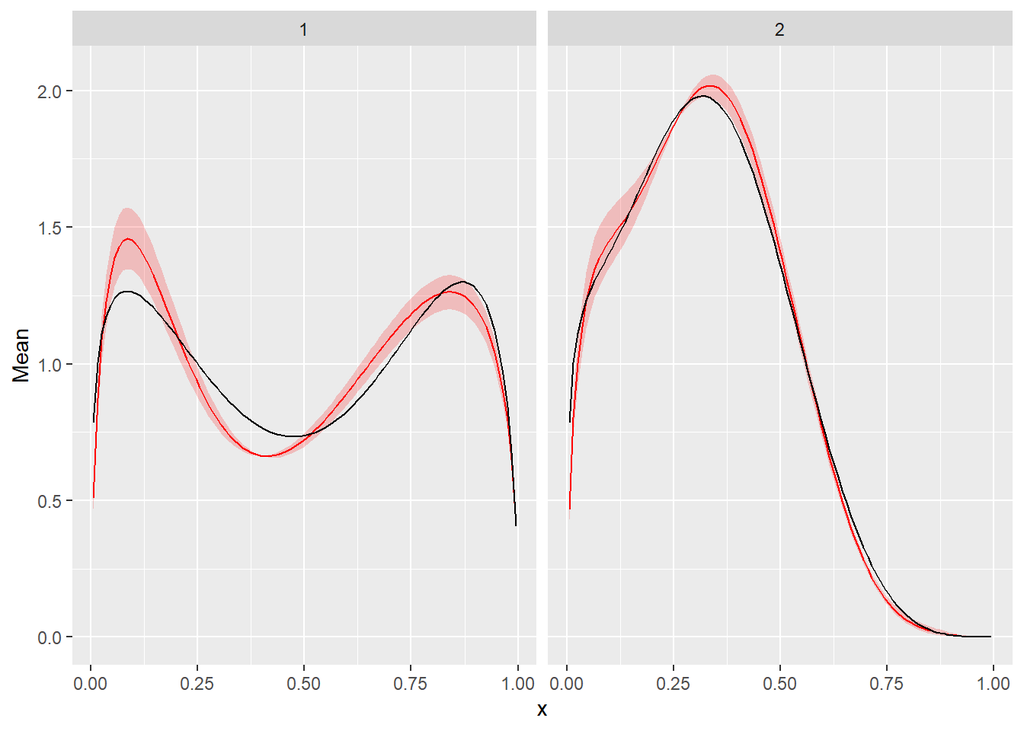

```r
xGrid <- ppoints(100)
postDraws <- lapply(dplist$indDP,
                    function(x) {
                      replicate(1000, PosteriorFunction(x)(xGrid))
                    }
                    )
postMeans <- lapply(postDraws, rowMeans)
postQuantiles <- lapply(postDraws,
                        function(x) {
                          apply(x, 1, quantile, probs=c(0.025, 0.975))
                        }
                        )


postFrame <- do.call(rbind,
                     lapply(seq_along(postMeans),
                            function(i) data.frame(Mean=postMeans[[i]],
                                                  t(postQuantiles[[i]]),
                                                  x=xGrid, ID=i)
                            )
                     )

trueFrame1 <- data.frame(y=0.5*dbeta(xGrid, a[1], b[1]) +
                           0.5*dbeta(xGrid, a[2], b[2]),
                         x=ppoints(100), ID=1)
trueFrame2 <- data.frame(y=0.5*dbeta(xGrid, a[1], b[1]) +
                           0.5*dbeta(xGrid, a[3], b[3]),
                         x=xGrid, ID=2)
trueFrame <- rbind(trueFrame1, trueFrame2)

library(ggplot2)
ggplot() +
  geom_ribbon(data=postFrame, aes(x=x, ymin=X2.5., ymax=X97.5.),
              alpha=0.2, colour=NA, fill="red") + #credible interval
  geom_line(data=postFrame, aes(x=x, y=Mean), colour="red") + #mean
  geom_line(data=trueFrame, aes(x=x, y=y)) + #true density
  facet_grid(~ID)
```

### *Example 4: Creating New Dirichlet process Mixture Types (Advanced Use)*

The `dirichletprocess` package is designed to be flexible and allow the user to create new Dirichlet process mixture models which are not currently implemented in the package. This is achieved by creating a new class which inherits from the `DirichletProcess` class and then overloading the necessary methods. To illustrate this, we show how simple it is to create a Dirichlet process mixture model with Poisson and Gamma distribution kernels, even though this is not implemented in the package.

Suppose we have a particular scenario that requires a Dirichlet process mixture of Poisson distributions. The conjugate prior for the Poisson distribution is the Gamma distribution.

First, we start with the likelihood of the Poisson distribution.

```r
Likelihood.poisson <- function(mdobj, x, theta){
return(as.numeric(dpois(x, theta[[1]])))
}
```

```r
PriorDraw.poisson <- function(mdobj, n){
draws <- rgamma(n, mdobj$priorParameters[1], mdobj$priorParameters[2])
theta <- list(array(draws, dim=c(1,1,n)))
return(theta)
}
```

The prior parameters $\alpha_0, \beta_0$ are stored in the mixing distribution object `mdobj`.We then write the `PosteriorDraw` function to sample from the posterior distribution of $\theta$. Again, as the base measure $G_0$ is conjugate this is a direct sample from the posterior distribution.
$$\theta |
x ∼ Gamma(\alpha_0 + \sum_{i=1}^{n} x_i, \beta_0 + n)$$
using the inbuilt `rgamma` function this is trivial.

```r
PosteriorDraw.poisson <- function(mdobj, x, n=1){
priorParameters <- mdobj$priorParameters
lambda <- rgamma(n, priorParameters[1] + sum(x), priorParameters[2] + nrow(x))
return(list(array(lambda, dim=c(1,1,n))))
}
```

Finally the marginal distribution of the data $f(y)$ can be evaluated as it is a conjugate mixture model and translated into the appropriate R function:

```r
Predictive.poisson <- function(mdobj, x){
  priorParameters <- mdobj$priorParameters
  pred <- numeric(length(x))
  for(i in seq_along(x)){
    alphaPost <- priorParameters[1] + x[i]
    betaPost <- priorParameters[2] + 1
    pred[i] <- (priorParameters[2] ^ priorParameters[1]) / gamma(priorParameters[1])
    pred[i] <- pred[i] * gamma(alphaPost) / (betaPost^alphaPost)
    pred[i] <- pred[i] * (1 / prod(factorial(x[i])))
  }
  return(pred)
}
```

With these functions written for the Poisson mixture model we now need to use the `MixingDistribution` constructor function to create a new object that can be used by the Dirichlet process constructor function, `DirichletProcessCreate`. The constructor function `MixingDistribution` creates an object of class `distribution`, in this case ’poisson’, with prior parameters $\alpha_0, \beta_0 = 1$ and that it is conjugate.

```r
poisMd <- MixingDistribution(distribution="poisson",
                             priorParameters = c(1, 1),
                             conjugate="conjugate")
```

This object is now ready to be used in a `dirichletprocess` object and the appropriate sampling tasks can be carried out. To demonstrate we simulate some test data and fit a Dirichlet process with our new mixing distribution.

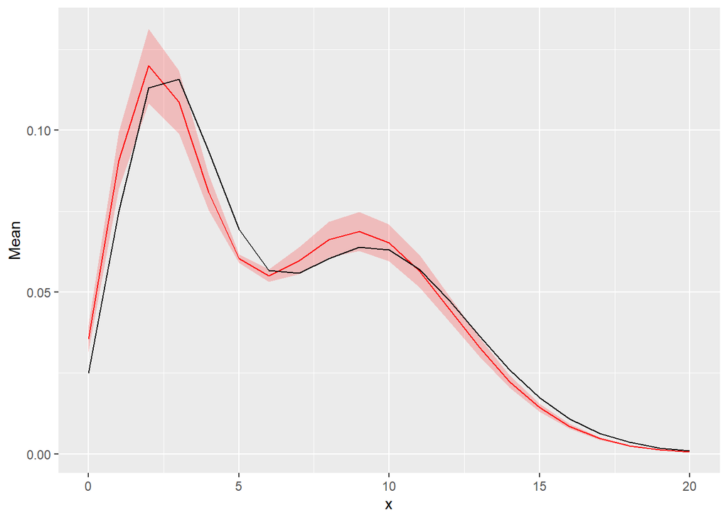

```r
set.seed(1234)
 y <- c(rpois(150, 3), rpois(150, 10))
#generate sample data
dp <- DirichletProcessCreate(y, poisMd)
dp <- Initialise(dp)
dp <- Fit(dp, 1000)
pf <- PosteriorFrame(dp, 0:20, 1000)
trueFrame <- data.frame(x= 0:20,
                        y= 0.5*dpois(0:20, 3) + 0.5*dpois(0:20, 10))

ggplot() +
  geom_ribbon(data=pf,
              aes(x=x, ymin=X5., ymax=X95.),
              colour=NA,
              fill="red",
              alpha=0.2) + #credible intervals
  geom_line(data=pf, aes(x=x, y=Mean), colour="red") + #mean
  geom_line(data=trueFrame, aes(x=x, y=y)) #true
```

As the figure shows, the true generating function has been recovered. This shows how easy it is for the user to create their own mixture models using the `dirichletprocess` package.

## Conclusion

The `dirichletprocess` package in R is a versatile tool for non-parametric Bayesian analysis, offering straightforward methods to fit DPMMs across various applications, including density estimation and clustering. Its support for multiple mixture kernels and the ability to define custom models make it a valuable resource for statisticians and data scientists.

Reference: - https://cran.r-project.org/web/packages/dirichletprocess/vignettes/dirichletprocess.pdf

- https://cran.r-project.org/web/packages/dirichletprocess/readme/README.html
- https://dm13450.github.io/2018/05/30/Clustering.html
- https://dm13450.github.io/2018/02/01/Dirichlet-Density.html
- https://www.stats.ox.ac.uk/~teh/teaching/npbayes/mlss2007.pdf